# Escuela de Software Libre

## Estructuras de Datos

## Tipos de datos estándar

Los datos almacenados en la memoria pueden ser de muchos tipos. Por ejemplo, la edad de una persona se almacena como un valor numérico y su dirección se almacena como caracteres alfanuméricos. Python tiene varios tipos de datos estándar que se utilizan para definir las operaciones posibles en ellos y el método de almacenamiento para cada uno de ellos.

- Numbers
- String
- List
- Tuple
- Diccionarie

## Datos Numéricos (Numbers)

Los tipos de datos numéricos almacenan valores numéricos. Los objetos numéricos se crean cuando les asigna un valor. Por ejemplo:

```python
var1 = 1
var2 = 10
```

También puede eliminar la referencia a un objeto numérico utilizando la instrucción `del`. La sintaxis de la declaración `del` es:

```python
del var1,var2
```

## Datos Numéricos (Numbers)

Python admite tres tipos numéricos diferentes:

- int (enteros con signo)
- float (valores reales, punto flotante)
- complex (número complejos)

```python
ent= 10
flt= 12.341245
cmpl= 2.3+7j
print(cmpl)
```

```
## (2.3+7j)
```

## Strings

Las cadenas en Python se identifican como un conjunto contiguo de caracteres representados en las comillas. Python permite cualquier par de comillas simples o dobles. Los subconjuntos de cadenas se pueden tomar usando el operador de división ( y [:]) con índices que comienzan en 0 al comienzo de la cadena y van desde -1 hasta el final.

El signo más (+) es el operador de concatenación de cadenas y el asterisco (*) es el operador de repetición. Por ejemplo:

```python
str = 'Hello World!'
print (str)          # Imprime el string
print (str[0])       # Imprime el primer carácter del string
print (str[2:5])     # Imprime caracteres del 3 al 5
print (str[2:])      # Imprime los caracteres del 3 en adelante
print (str * 2)      # Imprime el string dos veces
print (str + "TEST") # Imprime los strings concatenados
```

## Strings

El código anterior produce el siguiente resultado:

```
## Hello World!
```

```
## H
```

```
## llo
```

```
## llo World!
```

```
## Hello World!Hello World!
```

```
## Hello World!TEST
```

## Lists

Las listas son los tipos de datos compuestos más versátiles de Python. Una lista contiene elementos separados por comas y encerrados entre corchetes ([,]). Hasta cierto punto, las listas son similares a las matrices en C. Una de las diferencias entre ellas es que todos los elementos que pertenecen a una lista pueden ser de tipos de datos diferentes.

Se puede acceder a los valores almacenados en una lista utilizando el operador de división ([,] y [:]) con índices que comienzan en 0 al principio de la lista y avanzan hasta el final -1. El signo más (+) es el operador de concatenación de listas, y el asterisco (*) es el operador de repetición. Por ejemplo:

```python
list = [ 'abcd', 786 , 2.23, 'john', 70.2 ]
tinylist = [123, 'john']
print (list)          # Prints complete list
print (list[0])       # Prints first element of the list
print (list[1:3])     # Prints elements starting from 2nd till 3rd
print (list[2:])      # Prints elements starting from 3rd element
print (tinylist * 2)  # Prints list two times
print (list + tinylist) # Prints concatenated lists
```

## Lists

El código anterior produce el siguiente resultado:

```
## ['abcd', 786, 2.23, 'john', 70.2]
```

```
## abcd
```

```
## [786, 2.23]
```

```
## [2.23, 'john', 70.2]
```

```
## [123, 'john', 123, 'john']
```

```
## ['abcd', 786, 2.23, 'john', 70.2, 123, 'john']
```

## Tuples

Una tupla es otro tipo de datos de secuencia que es similar a la lista. Una tupla consiste en una serie de valores separados por comas. A diferencia de las listas, sin embargo, las tuplas se incluyen entre paréntesis.

La diferencia principal entre listas y tuplas es: las listas se incluyen entre corchetes ([,]) y sus elementos y tamaño se pueden cambiar, mientras que las tuplas se incluyen entre paréntesis ((,)) y no se pueden actualizar. Las tuplas se pueden considerar listas de solo lectura. Por ejemplo:

```python
tuple = ( 'abcd', 786 , 2.23, 'john', 70.2  )
tinytuple = (123, 'john')
print (tuple)           # Prints complete tuple
print (tuple[0])        # Prints first element of the tuple
print (tuple[1:3])      # Prints elements starting from 2nd till 3rd
print (tuple[2:])       # Prints elements starting from 3rd element
print (tinytuple * 2)   # Prints tuple two times
print (tuple + tinytuple) # Prints concatenated tuple
```

[output not shown]

## Tuples

El siguiente código no es válido con una `tuple`, porque intentamos actualizar una tupla, que no está permitida. Caso similar es posible con listas.

```python
tuple = ( 'abcd', 786 , 2.23, 'john', 70.2  )
list = [ 'abcd', 786 , 2.23, 'john', 70.2  ]
tuple[2] = 1000    # Invalid syntax with tuple
list[2] = 1000     # Valid syntax with list
```

## Dictionary

Los diccionarios de Python son tipo de tabla hash. Funcionan como arreglos asociativos o hashes encontrados en Perl y consisten en pares clave-valor. Una clave de diccionario puede ser casi cualquier tipo de Python, pero generalmente son números o cadenas. Los valores, por otro lado, pueden ser cualquier objeto arbitrario de Python.

Los diccionarios están encerrados con llaves ({,}) y los valores se pueden asignar y acceder usando llaves ([,]). Por ejemplo:

```python
dict = {}
dict['uno'] = "esto es uno"
dict[2]     = "esto es dos"
tinydict = {'nombre': 'david','codigo':6734, 'dept': 'ventas'}
print (dict['uno'])       # Prints value for 'one' key
print (dict[2])           # Prints value for 2 key
print (tinydict)          # Prints complete dictionary
print (tinydict.keys())   # Prints all the keys
print (tinydict.values()) # Prints all the values
```

## Dictionary

```
## esto es uno
```

```
## esto es dos
```

```
## {'nombre': 'david', 'codigo': 6734, 'dept': 'ventas'}
```

```
## dict_keys(['nombre', 'codigo', 'dept'])
```

```
## dict_values(['david', 6734, 'ventas'])
```

## Conversión del tipo de datos

A veces, puede necesitar realizar conversiones entre los tipos incorporados. Para convertir entre tipos, simplemente use los nombres de tipo como una función.

Hay varias funciones integradas para realizar la conversión de un tipo de datos a otro. Estas funciones devuelven un nuevo objeto que representa el valor convertido.

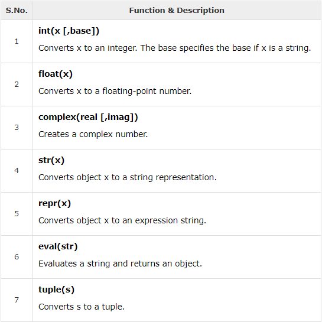

## Conversión del tipo de datos

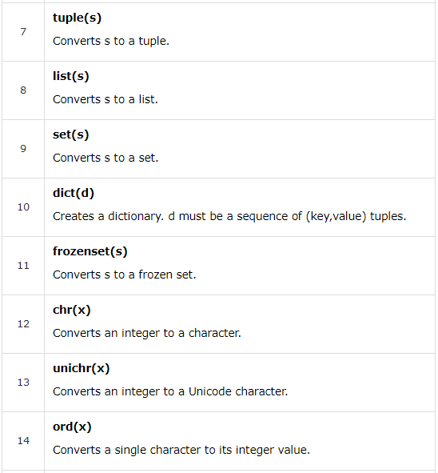

## Operadores

## Operadores Aritméticos

Supongamos que la variable a retiene el valor 10 y la variable b contiene el valor 21, luego:

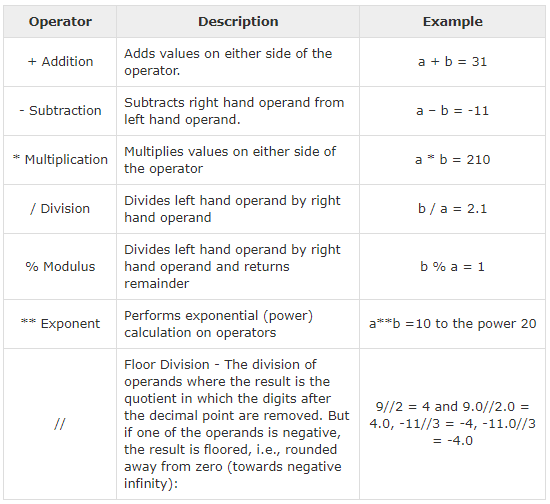

## Operadores de comparación

Estos operadores comparan los valores a ambos lados de ellos y deciden la relación entre ellos. También se les llama operadores relacionales.

Supongamos que la variable a tiene el valor 10 y la variable b contiene el valor 20, luego

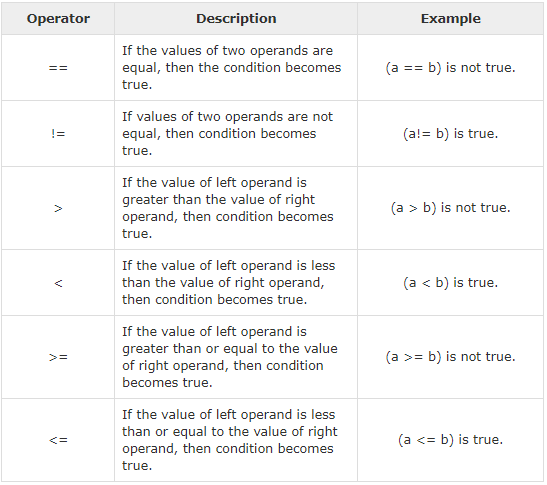

## Operadores de Asignación

Supongamos que la variable a tiene el valor 10 y la variable b contiene el valor 20, luego

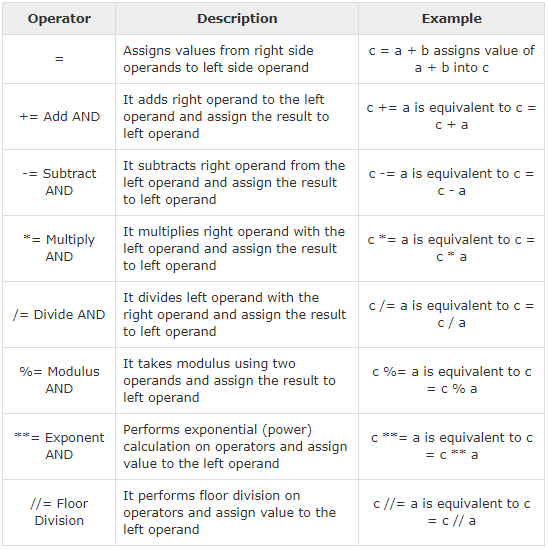

## Operadores Lógicos

Los siguientes operadores lógicos son compatibles con el lenguaje Python. Suponer que la variable **a** es `True` y la variable **b** contiene `False` luego:

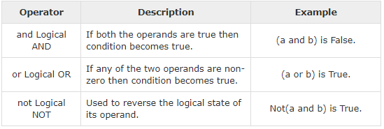

## Operadores de Pertenencia (Membership)

Los operadores de membresía de Python evalúan la membresía en una secuencia, como cadenas, listas o tuplas. Hay dos operadores de membresía como se explica a continuación

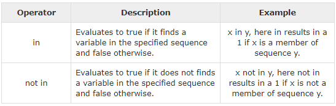

## Operadores de Identidad

Los operadores de identidad comparan las ubicaciones de memoria de dos objetos. Hay dos operadores de identidad como se explica a continuación

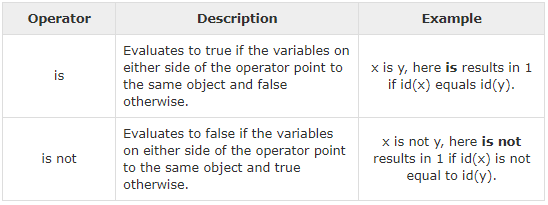

## Precedencia

La siguiente tabla enumera todos los operadores desde la precedencia(órden de ejecución) más alta hasta la más baja.

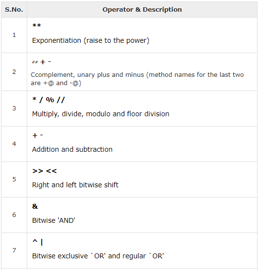

## Precedencia

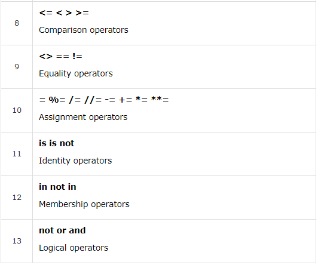

## Estructuras de Control

## Condicionales

Las estructuras de decisión evalúan expresiones múltiples, que producen VERDADERO o FALSO como resultado. Debe determinar qué acción tomar y qué declaraciones ejecutar si el resultado es VERDADERO o FALSO.

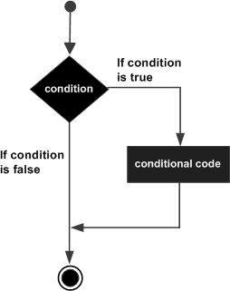

## Condicionales (if)

```python
var1 = 100
if var1:
   print ("1 - Got a true expression value")
   print (var1)
var2 = 0
if var2:
   print ("2 - Got a true expression value")
   print (var2)
print ("Good bye!")
```

## Condicionales (if - else)

Una instrucción else se puede combinar con una instrucción if. Una instrucción else contiene un bloque de código que se ejecuta si la expresión condicional en la instrucción if resulta ser 0 o en un valor FALSO.

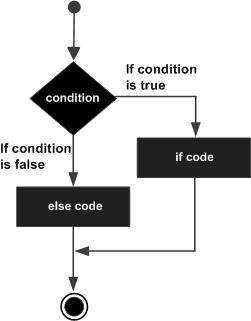

## Condicionales (if - else)

```python
amount = int(input("Enter amount: "))
if amount<1000:
   discount = amount*0.05
   print ("Discount",discount)
else:
   discount = amount*0.10
   print ("Discount",discount)

print ("Net payable:",amount-discount)
```

## Sentencia (elif)

La instrucción elif le permite verificar múltiples expresiones para VERDADERO y ejecutar un bloque de código tan pronto como una de las condiciones se evalúe como VERDADERO.

```python
amount = int(input("Enter amount: "))
if amount<1000:
   discount = amount*0.05
   print ("Discount",discount)
elif amount<5000:
   discount = amount*0.10
   print ("Discount",discount)
else:
   discount = amount*0.15
   print ("Discount",discount)

print ("Net payable:",amount-discount)
```